# Exploratory data analysis and Modelization

### 4.2. scatterplots with the 5 numeric relevant variables. Linear relationship.

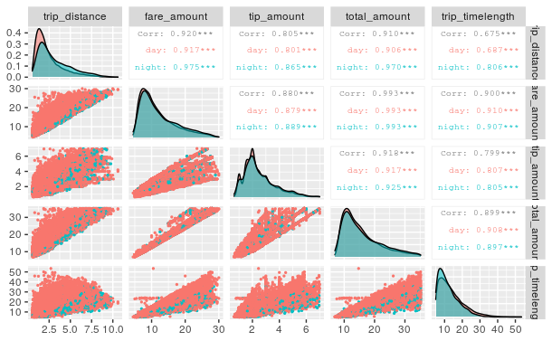

```r
library(GGally)
ggpairs(data[,c(5,11,14,17,18)], aes(colour = data$t_puH, alpha = 0.4), upper = list(continuous = wrap("cor", size=2.5)),lower = list(continuous = wrap(funcVal="points", alpha = 1, size=0.5)))
```

Main differences are found in the time length of the trips, where the daytime records show data where the same distance takes longer in comparison with night-time recors. These 2 variables are the ones that correlates less, although night data correlates better.

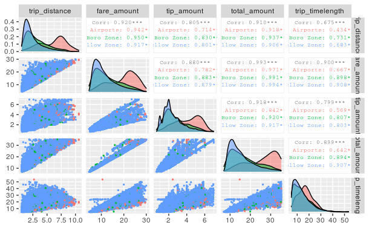

```r
ggpairs(data[, c(5,11,14,17,18)], aes(colour = data$PU_servicezone, alpha = 0.4), upper = list(continuous = wrap("cor", size=2.5)),lower = list(continuous = wrap(funcVal="points", alpha = 1, size=0.5)))
```

Also we observe how most of the data of airports have a different distribution compared to the other areas. In general, trips from the airport are more expensive an takes more time. Aditionally the tip amount is higher. If we check if this also happends with the tip %:

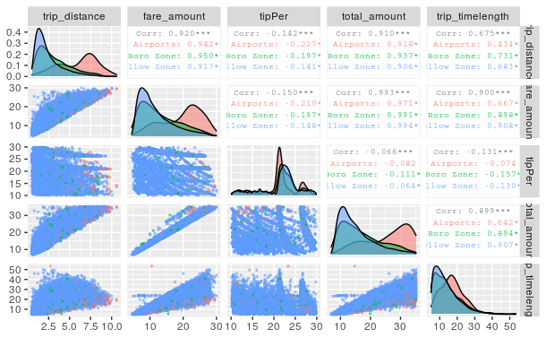

```r
df <- data
df$tipPer <- data[,14]/data[,11]*100

ggpairs(df[, c(5,11,29,17,18)], aes(colour = df$PU_servicezone, alpha = 0.4), upper = list(continuous = wrap("cor", size=2.5)),lower = list(continuous = wrap(funcVal="points", alpha = 0.5, size=0.5)))
```

In this case, the % tip is centered in 20-25% when the taxi is picked up in the Yellow or Boro Zone. In the case of the airports, we see a bimodal distribution, with a second maximum beyond 25%. However, it is important to notice that the amount of data from boroughs different to Manhattan is scarce.

### 4.3 Mean variables by Location ID

#### Spatial representation of the mean tip % depdending on the pick up location ID.

```r
data$tipPer <-data[,14]/data[,11]*100
PU_tip<- data %>%
    group_by(PULocationID) %>%
    summarise(no_rows =  mean(tipPer)) %>%
    as.data.frame()
names(PU_tip) <- c("LocationID","PU_mean")
DO_tip<- data %>%
    group_by(DOLocationID) %>%
    summarise(no_rows =  mean(tipPer)) %>%
    as.data.frame()
names(DO_tip) <- c("LocationID","DO_mean")
```

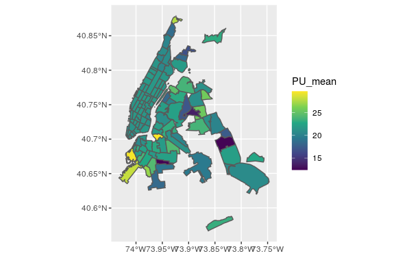

```r
d <- merge(spZones, PU_tip, by='LocationID')
pu_tip<-  ggplot() + geom_sf(data=d, aes(fill = PU_mean))+scale_fill_continuous(type='viridis')

e <- merge(spZones, DO_tip, by='LocationID')
do_tip<-  ggplot() + geom_sf(data=e, aes(fill = DO_mean))+scale_fill_continuous(type='viridis')
pu_tip
```

Most of the locations are around 20 to 23 but few of them present values below 15 and above 25.

We can present the same as previous figure but depending on the drop off location.

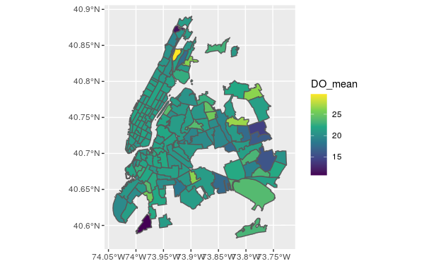

```r
do_tip
```

In this cse there is one location with high values with respect to the others. In general there is homogenity.

#### Spatial representation of the mean trip distance depdending on the pick up location ID.

```r
PU_length  <-  data %>%
    group_by(PULocationID) %>%
    summarise(no_rows = mean(trip_distance))%>%
    as.data.frame()
names(PU_length) <- c("LocationID","PU_length")
DO_length  <-  data %>%
    group_by(DOLocationID) %>%
    summarise(no_rows = mean(trip_distance))%>%
    as.data.frame()
names(DO_length) <- c("LocationID","DO_length")
```

For the pick up location:

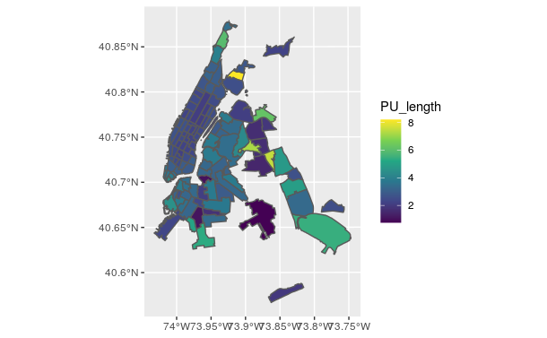

```r
f  <- merge(spZones, PU_length, by='LocationID')
pu_length  <- ggplot() + geom_sf(data=f, aes(fill = PU_length))+scale_fill_continuous(type='viridis')
g  <- merge(spZones, DO_length, by='LocationID')
do_length  <- ggplot() + geom_sf(data=g, aes(fill = DO_length))+scale_fill_continuous(type='viridis')
pu_length
```

The trip length maximum is around 8 miles. Most of the trips are around 4. Inside Manhattan trip length is around 2 miles.

And the drop off:

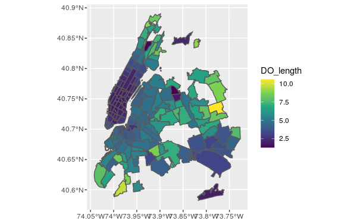

```r
do_length
```

The same map representation but depdending on the drop off shows different values. It seems to be a cluster centered in Manhattan with the lower values and largest values goes to the margins of the figure (in general). This has sense if we consider that most of the trips comes from the Manhattan area, so the distance increases for the locations far from that borough.

# 5. Conclusions

Some insights can be derived from the dataset of the taxi data:

About the exploratory analysis:

- The taxi tips distribution have a maximum around 20 to 25 %.
- Some linear relationship is found between the tip amount and: fare amount, trip distance, trip duration
- Most of the data records are from and to Manhattan
- Most of the trips are made during the day
- The distribution of the trips inside the same borough is different from those trips that are picked up in one borough and finished in a different one.

# MODELIZATION

## 1. Data preparation

The data is download from the website. As in the exploratory analysis, a sample of the data is used, due to the computational limitations.

### 1.1 Cleaning

After reading the data, it is cleaned taking into account the findings of the exploratory data analysis and some new variables are included:

In the cleaning phase:

- Remove the N/A values of the data
- - fare > 0
  - trip distance > 0
  - extra charges >= 0
  - tolls >= 0
  - total amount > 0
  - improvement surchage == 0.3
  - passesngers >= 0

The other variables included are: * Duration of the trip * The day of the week * The ‘intratrip’ variable

The prepared data is stored as a .csv called *taxi_model_sample_data.csv*. The script where this is done is called: model_sample.R

### 1.2 Sample data

The dataset is then divided: 80% of the data is used as training data and the other 20% is used to test the model.

```r
data <- read.csv("data/taxi_model_sample_data.csv")
#########################
## sample the data for modelling:
# Random sample indexes
train_index <- sample(1:nrow(data), 0.8 * nrow(data))
test_index <- setdiff(1:nrow(data), train_index)
# Build X_train, y_train, X_test, y_test
X_train <- data[train_index, -3]
y_train <- data[train_index, "tip_amount"]
X_test <- data[test_index, -3]
y_test <- data[test_index, "tip_amount"]
## save these datasets:
write.csv(X_train, "data/xtrain.csv", row.names=FALSE)
write.csv(y_train, "data/ytrain.csv",row.names=FALSE)
write.csv(X_test, "data/xtest.csv",row.names=FALSE)
write.csv(y_test, "data/ytest.csv",row.names=FALSE)
```

## 2. Model run

Code for the model run can be found in ‘model_run.R’, but I will reproduce it here.

```r
## Built and run the model
## As seen in the EDA there is linear relationship among the numeric variables selected. Some of them are linear dependent on other, what should be seen in our model.
library(MASS)
## Load the train data:
xtrain <- read.csv("data/xtrain.csv")
ytrain <- read.csv("data/ytrain.csv")
train  <- cbind(ytrain, xtrain)
names(train)  <- c("tip_amount",names(xtrain))
```

### 2.1. Multivariate regression model

We first test a multivariate linear regression model. The numerical variables include will be the fare amount, the trip duration, the trip distance. Additionally we will include 2 categorical variables: the day of the week and if the trip is inside the same borough or not (the ‘intratrip’ variable).

**Run the model**

```r
## 1.1 model: use all the variables except the total amount that depends on the dependent variable 'tip'.
train <- train[, -4]
lm  <- lm(tip_amount~. ,data=train)
summary(lm)
```

```
Call:
lm(formula = tip_amount ~ ., data = train)

Residuals:
    Min      1Q  Median      3Q     Max
-6.7698 -0.0972  0.1067  0.1900  5.0343

Coefficients:
                   Estimate Std. Error t value Pr(>|t|)
(Intercept)       0.1355246  0.0114076  11.880  < 2e-16 ***
trip_distance    -0.0070794  0.0060518  -1.170  0.24209
fare_amount       0.1997576  0.0030784  64.889  < 2e-16 ***
trip_timelength   0.0009507  0.0011319   0.840  0.40096
intratripyes      0.2051436  0.0076384  26.857  < 2e-16 ***
weekdayjueves     0.0274872  0.0101337   2.712  0.00668 **
weekdaylunes      0.0434453  0.0106017   4.098 4.17e-05 ***
weekdaymartes     0.0331740  0.0105438   3.146  0.00165 **
weekdaymiércoles  0.0336149  0.0102180   3.290  0.00100 **
weekdaysábado    -0.0142392  0.0107738  -1.322  0.18629
weekdayviernes    0.0123596  0.0101444   1.218  0.22309
---
Signif. codes:  0 ‘***’ 0.001 ‘**’ 0.01 ‘*’ 0.05 ‘.’ 0.1 ‘ ’ 1

Residual standard error: 0.6516 on 105364 degrees of freedom
Multiple R-squared:  0.8629,    Adjusted R-squared:  0.8628
F-statistic: 6.629e+04 on 10 and 105364 DF,  p-value: < 2.2e-16
```

```r
##confidence  <- confint(lm)
lm$coefficients
```

```
     (Intercept)    trip_distance      fare_amount  trip_timelength     intratripyes    weekdayjueves     weekdaylunes
    0.1355246441    -0.0070793513     0.1997575699     0.0009506542     0.2051436402     0.0274871609     0.0434453341
   weekdaymartes weekdaymiércoles    weekdaysábado   weekdayviernes
    0.0331740220     0.0336149087    -0.0142391748     0.0123595652
```

The training show a good performance of the linear regression. We can check for the importance of the different variables in the summary of the model.

**Test the model**

```r
xtest  <- read.csv("data/xtest.csv")
xtest <- xtest[,-3] ## remove the total amount
ytest  <- read.csv("data/ytest.csv")
predictions  <- predict(lm, xtest, interval="prediction")
results  <- cbind(ytest, predictions)
tail(results)
```

```
         x      fit       lwr      upr
26339 1.86 1.744462 0.4672827 3.021641
26340 2.56 2.363749 1.0865590 3.640938
26341 2.70 4.532324 3.2551121 5.809536
26342 2.35 2.241711 0.9645341 3.518887
26343 3.75 3.665190 2.3879731 4.942407
26344 3.25 3.076891 1.7996734 4.354109
```

The xyplot for the test and predicted:

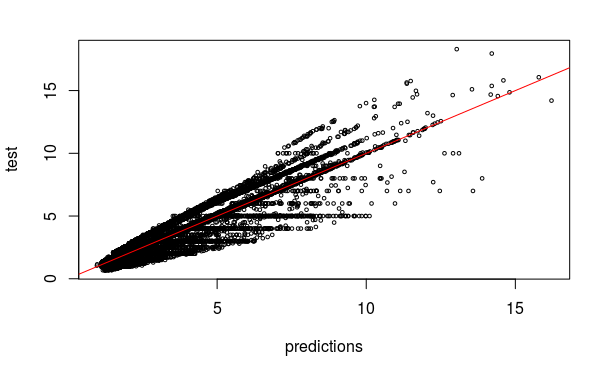

```r
plot(results$x~results$fit, xlab='predictions', ylab='test', cex=0.5)
abline(0,1, col='red')
```

We can check the predictions and we can also see that the errors are normally distributed.

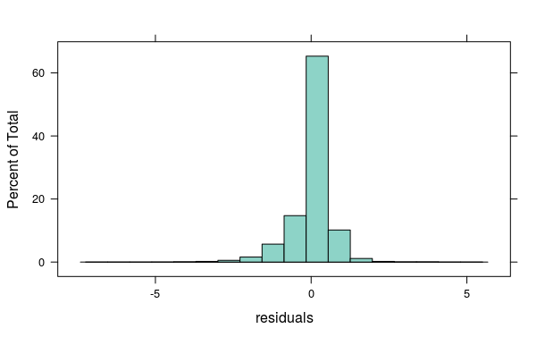

```r
## Normal distribution of residuals.
histogram(lm$residuals, par.settings=myTheme, xlab='residuals')
```

```r
## RMSE
RMSE_lm <- sqrt(mean((results$x - results$fit)^2))
RMSE_lm
```

```
[1] 0.655387
```

However, the variance of the residuals is not constant, which means that the linear model may not be the best solution to this problem. It could be that we are missing some predictors or that some of the data collectd (those records with constant tip regardless the fare) cannot be used in the model.

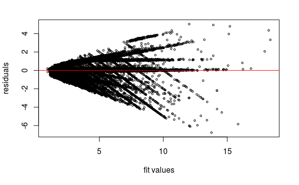

```r
plot(lm$residuals~lm$fitted.values, cex=0.5, xlab='fit values', ylab='residuals')
abline(c(0,0), col='red')
```

### 2.2 Random Forest

We now check a random forest in order to check if it improves the predictions of the multilinear model.

**Run the model**

```r
library(randomForest)

# It takes long
rf_model <- randomForest(tip_amount ~., data = train,  importance = TRUE, ntree=300)
rf_model
importance(rf_model)[,1] ## show the importance of the variables
```

[output not shown]

**Test the model**

```r
rf_predict <- predict(rf_model, xtest)

results  <- cbind(ytest, rf_predict)

plot(results$x~results$rf_predict, xlab='predictions', ylab='test', cex=0.5)
abline(0,1, col='red')
```

[output not shown]

```r
## R2
RMSE_rf <- sqrt(mean((results$x-results$rf_predict)^2))
RMSE_rf
```

```
[1] NaN
```

```r
err  <- round((abs(results$x-results$rf_predict)/results$x)*100, digits=1)
histogram(err, par.settings=myTheme)
```

[output not shown]

# FURTHER ANALYSIS

In order to go beyond this analysis:

- We could enrich the analysis with data from every month of the year, in order to investigate **seasonality** in the data. Up to now only three months have been considered, so the complete *annual cycle* could be interesting to see if there is seasonality.
- A global picture of the whole “taxi” sector is better done with all the datasets from other types of vehicles. In this analysis, only the ‘yellow’ taxi data is used, so it would be better to include the rest of the datasets.
- We could also look for other variables that potentially could be interesting for the tip variable. Like knowing about the most dense **traffic hours** in each area, some **weather data** to look for patterns in the temporal series, etc.
- As seen in the data, the tip amount have a clear linear pattern with different slopes. If it could be done a first classification to separate the lines with different slopes, the regression problem adapted to each case would work better.